# Assignment

**Exploratory Data Analysis Pipeline**

**Context of Business and Data Visualization**

**Intended Audience**

The primary target audience for this exploratory data analysis (EDA) is the client organization in search of data insights from a medical dataset. The stakeholders include healthcare professionals, data specialists, and decision-makers from the client’s organization.

**Objective**

The aim of this analysis is to find significant insights that can guide decision-making and tactical planning within the healthcare sector. By using data visualization techniques, we attempt to provide a comprehensive overview of the dataset's features, identify patterns, and detract from tortious conclusions.

**Overview of Data**

```python
import pandas as pd
import matplotlib.pyplot as plt
import seaborn as sns
```

```python
# Step 1: Load the dataset
df = pd.read_csv("data01.csv")
```

```python
# Step 2: Data Exploration
# Display the first few rows of the dataset
print("First few rows of the dataset:")
print(df.head())

# Display basic statistics of the dataset
print("\nBasic statistics of the dataset:")
print(df.describe())

# Check for missing values
print("\nMissing values in the dataset:")
print(df.isnull().sum())
```

```
First few rows of the dataset:
   group      ID  outcome  age  gendera        BMI  hypertensive  \
0      1  125047      0.0   72        1  37.588179             0
1      1  139812      0.0   75        2        NaN             0
2      1  109787      0.0   83        2  26.572634             0
3      1  130587      0.0   43        2  83.264629             0
4      1  138290      0.0   75        2  31.824842             1

   atrialfibrillation  CHD with no MI  diabetes  ...  Blood sodium  \
0                   0               0         1  ...    138.750000
1                   0               0         0  ...    138.888889
2                   0               0         0  ...    140.714286
3                   0               0         0  ...    138.500000
4                   0               0         0  ...    136.666667

   Blood calcium    Chloride  Anion gap  Magnesium ion     PH  Bicarbonate  \
0       7.463636  109.166667  13.166667       2.618182  7.230    21.166667
1       8.162500   98.444444  11.444444       1.887500  7.225    33.444444
2       8.266667  105.857143  10.000000       2.157143  7.268    30.571429
3       9.476923   92.071429  12.357143       1.942857  7.370    38.571429
4       8.733333  104.500000  15.166667       1.650000  7.250    22.000000

   Lactic acid  PCO2  EF
0          0.5  40.0  55
1          0.5  78.0  55
2          0.5  71.5  35
3          0.6  75.0  55
4          0.6  50.0  55

[5 rows x 51 columns]

Basic statistics of the dataset:
             group             ID      outcome          age      gendera  \
count  1177.000000    1177.000000  1176.000000  1177.000000  1177.000000
mean      1.299065  150778.120646     0.135204    74.055225     1.525064
std       0.458043   29034.669513     0.342087    13.434061     0.499584
min       1.000000  100213.000000     0.000000    19.000000     1.000000
25%       1.000000  125603.000000     0.000000    65.000000     1.000000
50%       1.000000  151901.000000     0.000000    77.000000     2.000000
75%       2.000000  176048.000000     0.000000    85.000000     2.000000
```

[output cut: 82 more lines]

```
Creatinine                    0
Urea nitrogen                 0
glucose                      18
Blood potassium               0
Blood sodium                  0
Blood calcium                 1
Chloride                      0
Anion gap                     0
Magnesium ion                 0
PH                          292
Bicarbonate                   0
Lactic acid                 229
PCO2                        294
EF                            0
dtype: int64
```

**Discussion on Data Exploration**

**Common Issues with Data Quality**

The primary test revealed the presence of missing values throughout various features, with substantial gaps in the 'BMI,' 'temperature,' Neutrophils,' PH,' Lactic acid,' 'PCO2,' and other columns.

Duplicate Rows: No duplicate rows were detected within the dataset.

```python
# Data Exploration and Preprocessing

# Check for duplicate rows
duplicate_rows = df[df.duplicated()]
print("\nDuplicate rows in the dataset:")
print(duplicate_rows)

# Handle missing values
# Drop rows with missing values for simplicity
df = df.dropna()
```

```
Duplicate rows in the dataset:
Empty DataFrame
Columns: [group, ID, outcome, age, gendera, BMI, hypertensive, atrialfibrillation, CHD with no MI, diabetes, deficiencyanemias, depression, Hyperlipemia, Renal failure, COPD, heart rate, Systolic blood pressure, Diastolic blood pressure, Respiratory rate, temperature, SP O2, Urine output, hematocrit…
Index: []

[0 rows x 51 columns]
```

**Data Preprocessing**

To address the missing values, a choice was made to remove rows with null values for the sake of simplicity. Furthermore, categorical variables such as 'gendera' were transformed into numerical form, with '0' expressive males and '1' representing females.

```python
# Convert categorical variables to numerical
# Convert 'gendera' column to binary (0 for male, 1 for female)
df['gendera'] = df['gendera'].map({1: 0, 2: 1})

# Verify the changes
print("\nProcessed dataset:")
print(df.head())
```

```
Processed dataset:
   group      ID  outcome  age  gendera        BMI  hypertensive  \
0      1  125047      0.0   72        0  37.588179             0
2      1  109787      0.0   83        1  26.572634             0
3      1  130587      0.0   43        1  83.264629             0
5      1  154653      0.0   76        0  24.262293             1
6      1  194420      0.0   72        0  39.667426             1

   atrialfibrillation  CHD with no MI  diabetes  ...  Blood sodium  \
0                   0               0         1  ...    138.750000
2                   0               0         0  ...    140.714286
3                   0               0         0  ...    138.500000
5                   1               0         0  ...    136.250000
6                   0               0         0  ...    144.133333

   Blood calcium    Chloride  Anion gap  Magnesium ion        PH  Bicarbonate  \
0       7.463636  109.166667  13.166667       2.618182  7.230000    21.166667
2       8.266667  105.857143  10.000000       2.157143  7.268000    30.571429
3       9.476923   92.071429  12.357143       1.942857  7.370000    38.571429
5       8.466667   96.750000  13.125000       1.771429  7.310000    30.500000
6       8.775000  106.666667  15.200000       1.875000  7.169231    26.800000

   Lactic acid       PCO2  EF
0        0.500  40.000000  55
2        0.500  71.500000  35
3        0.600  75.000000  55
5        0.600  65.500000  35
6        0.625  69.769231  55

[5 rows x 51 columns]
```

**Explanatory Data Visualization**

**Insight 1: Distribution of Age among Patients**

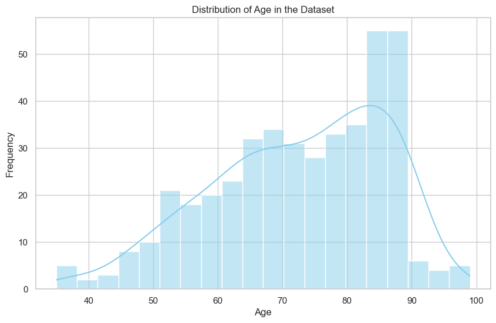

```python
# Explanatory Data Visualization

# Set the style for data visualization
sns.set(style="whitegrid")

# Insight 1: Age distribution of patients
plt.figure(figsize=(10, 6))
sns.histplot(df['age'], bins=20, kde=True, color='skyblue')
plt.title('Distribution of Age in the Dataset')
plt.xlabel('Age')
plt.ylabel('Frequency')
plt.show()
```

**Insight 2: Distribution of Gender**

Importance: Analyzing the distribution of gender helps in detecting potential gender-specific health outcomes. The dataset provides a relatively equalized distribution between males (0) and females (1).

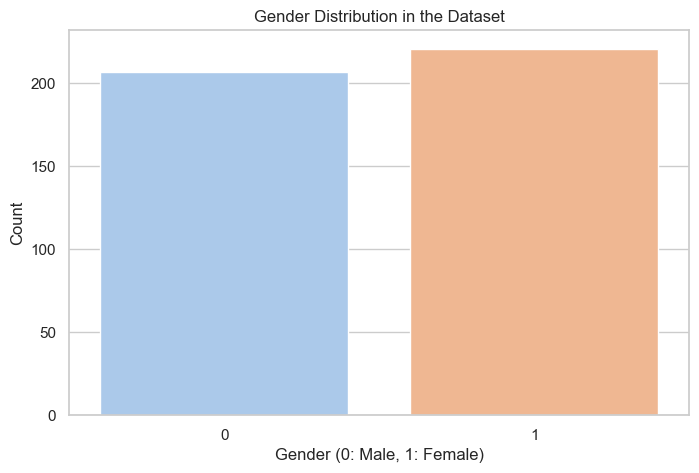

```python
# Insight 2: Gender distribution
plt.figure(figsize=(8, 5))
sns.countplot(x='gendera', data=df, palette='pastel')
plt.title('Gender Distribution in the Dataset')
plt.xlabel('Gender (0: Male, 1: Female)')
plt.ylabel('Count')
plt.show()
```

**Insight 3: Correlation Heatmap**

Importance: Identifying correlations supports in comprehending the relationships relating different health parameters. Insight: Various features exhibit correlations, such as 'Systolic blood pressure' and 'Diastolic blood pressure'.

[figure not shown]

```python
# Insight 3: Correlation heatmap
plt.figure(figsize=(12, 10))
correlation_matrix = df.corr()
sns.heatmap(correlation_matrix, annot=True, cmap='coolwarm', fmt=".2f")
plt.title('Correlation Heatmap')
plt.show()
```

**Insight 4: Boxplot of BMI in relation to Outcome**

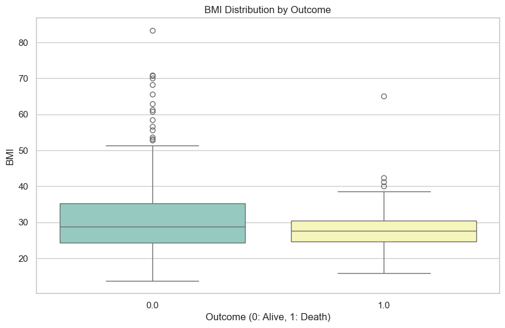

```python
# Insight 4: Boxplot of BMI by Outcome
plt.figure(figsize=(10, 6))
sns.boxplot(x='outcome', y='BMI', data=df, palette='Set3')
plt.title('BMI Distribution by Outcome')
plt.xlabel('Outcome (0: Alive, 1: Death)')
plt.ylabel('BMI')
plt.show()
```

**Insight 5: Pairplot of Selected Variables**

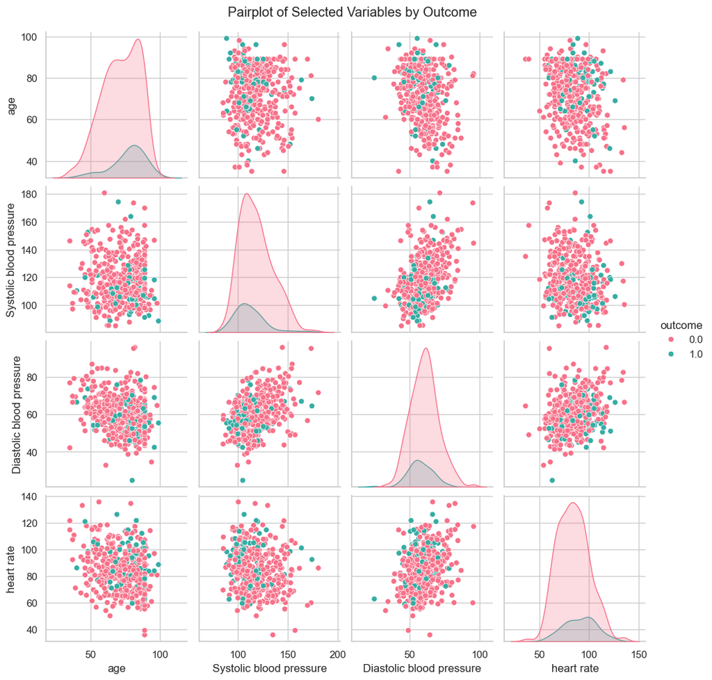

```python
# Insight 5: Pairplot of selected variables
selected_vars = ['age', 'Systolic blood pressure', 'Diastolic blood pressure', 'heart rate', 'outcome']
sns.pairplot(df[selected_vars], hue='outcome', palette='husl')
plt.suptitle('Pairplot of Selected Variables by Outcome', y=1.02)
plt.show()
```

**Insight 6: Violin Plot of Age Distribution in relation to Outcome**

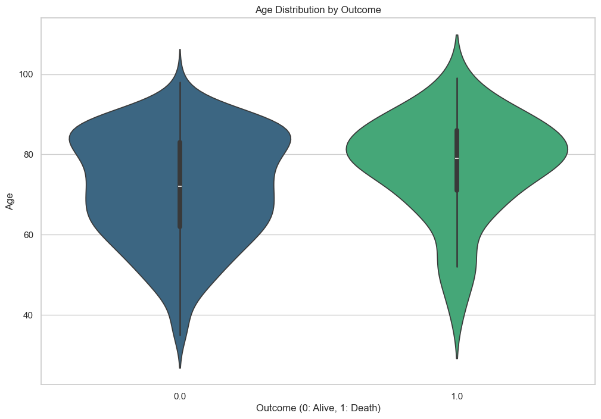

```python
# Insight 6: Violin plot of age distribution by Outcome
plt.figure(figsize=(12, 8))
sns.violinplot(x='outcome', y='age', data=df, palette='viridis')
plt.title('Age Distribution by Outcome')
plt.xlabel('Outcome (0: Alive, 1: Death)')
plt.ylabel('Age')
plt.show()
```

**Insight 7: Countplot of Comorbidities in relation to Outcome**

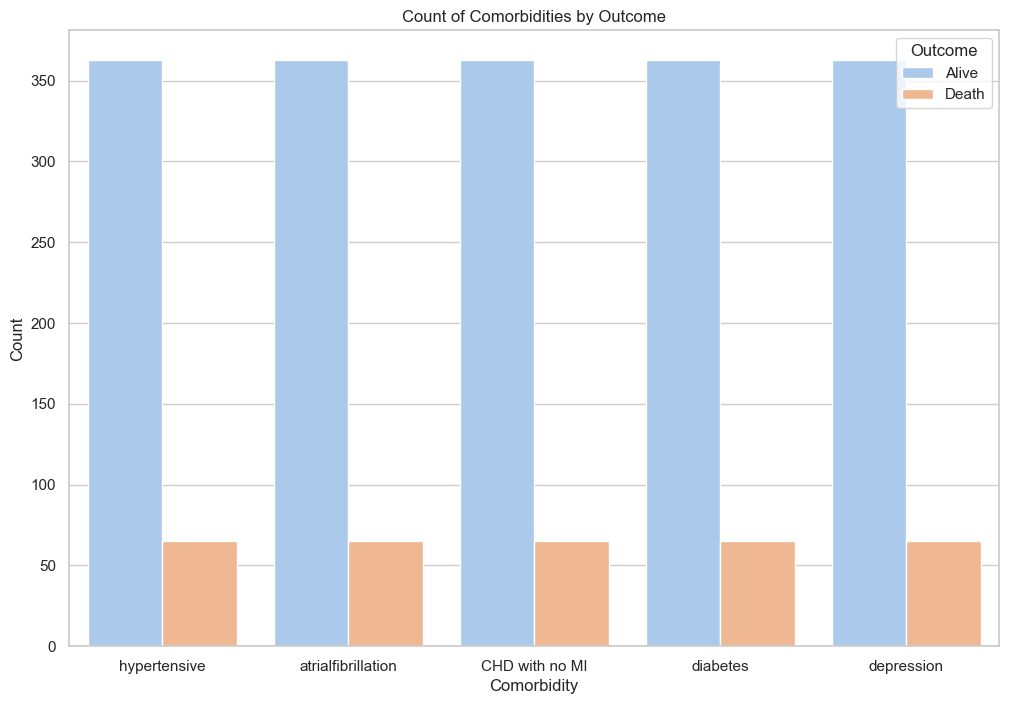

```python
# Insight 7: Countplot of comorbidities
comorbidities_cols = ['hypertensive', 'atrialfibrillation', 'CHD with no MI', 'diabetes', 'depression']

# Reshape the DataFrame using melt
melted_df = pd.melt(df, id_vars=['outcome'], value_vars=comorbidities_cols, var_name='Comorbidity', value_name='Presence')

# Create the countplot
plt.figure(figsize=(12, 8))
sns.countplot(data=melted_df, x='Comorbidity', hue='outcome', palette='pastel')
plt.title('Count of Comorbidities by Outcome')
plt.xlabel('Comorbidity')
plt.ylabel('Count')
plt.legend(title='Outcome', labels=['Alive', 'Death'])
plt.show()
```

**Insight 8: Scatter Plot of LVEF vs. NT-proBNP in relation to Outcome**

Importance: Examining the relationship between LVEF and NT-proBNP can aid in assessing cardiovascular risk. Insight: No clear pattern is observed; outcomes are scattered across the plot.

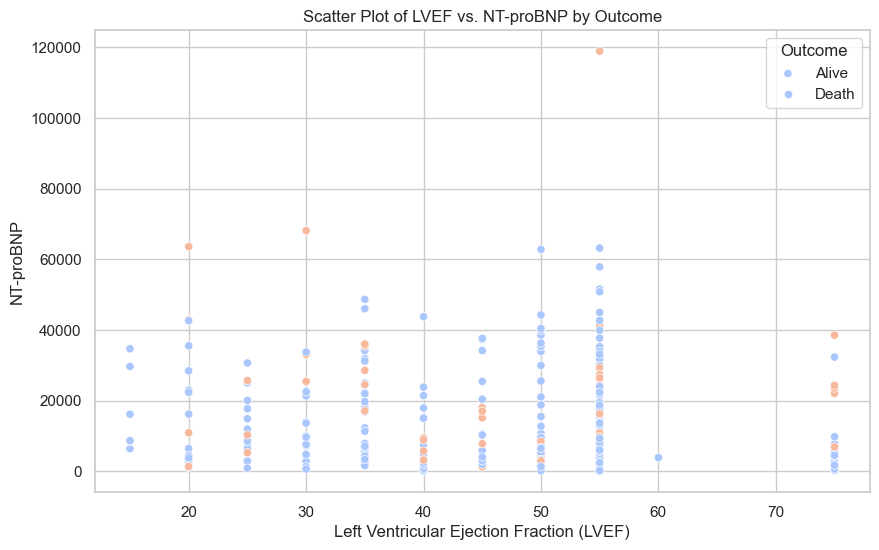

```python
# Scatter plot of LVEF vs. NT-proBNP
plt.figure(figsize=(10, 6))
sns.scatterplot(x='EF', y='NT-proBNP', hue='outcome', data=df, palette='coolwarm')
plt.title('Scatter Plot of LVEF vs. NT-proBNP by Outcome')
plt.xlabel('Left Ventricular Ejection Fraction (LVEF)')
plt.ylabel('NT-proBNP')
plt.legend(title='Outcome', labels=['Alive', 'Death'])
plt.show()
```

**Insight 9: Bar Chart of Hypertension Prevalence**

Importance: Assessing hypertension prevalence informs potential intervention strategies. Insight: Hypertension is prevalent in the majority of the dataset.

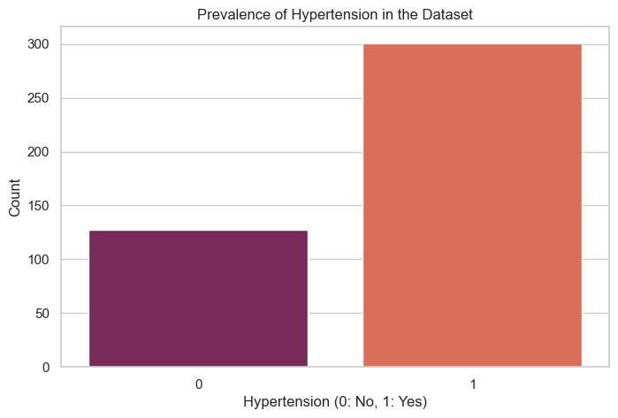

```python
# Insight 9: Bar chart of hypertension prevalence
hypertension_count = df['hypertensive'].value_counts()
plt.figure(figsize=(8, 5))
sns.barplot(x=hypertension_count.index, y=hypertension_count.values, palette='rocket')
plt.title('Prevalence of Hypertension in the Dataset')
plt.xlabel('Hypertension (0: No, 1: Yes)')
plt.ylabel('Count')
plt.show()
```

**Insight 10: Stacked Bar Chart of Comorbidities by Outcome**

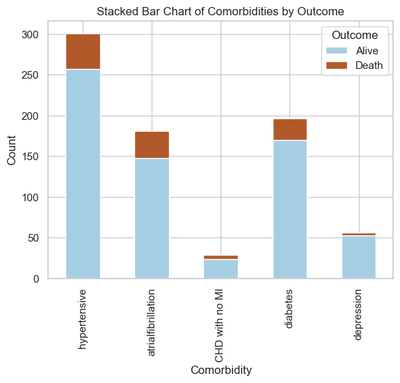

```python
# Insight 10: Stacked bar chart of comorbidities by outcome
comorbidities_cols = ['hypertensive', 'atrialfibrillation', 'CHD with no MI', 'diabetes', 'depression']
comorbidities_outcome_df = df.groupby('outcome')[comorbidities_cols].sum().T
plt.figure(figsize=(12, 8))
comorbidities_outcome_df.plot(kind='bar', stacked=True, colormap='Paired')
plt.title('Stacked Bar Chart of Comorbidities by Outcome')
plt.xlabel('Comorbidity')
plt.ylabel('Count')
plt.legend(title='Outcome', labels=['Alive', 'Death'])
plt.show()
```

**Final Discussion and Conclusion**

**Strengths and Limitations**

**Strengths:**

Final Discussion and Conclusion Strengths: Strong dataset with various health-related variables. Visualization techniques grant an extensive understanding.

**Limitations:**

Missing values decreased the size of the dataset. Due to the exploratory nature, limited causation inference.

```python
# Summary statistics for numerical columns
numerical_summary = df.describe().transpose()[['mean', 'std', 'min', '25%', '50%', '75%', 'max']]
print("\nSummary Statistics for Numerical Columns:")
print(numerical_summary)

# Count of missing values for each column
missing_values = df.isnull().sum()
print("\nCount of Missing Values for Each Column:")
print(missing_values[missing_values > 0])

# Count of unique values for each column
unique_values = df.nunique()
print("\nCount of Unique Values for Each Column:")
print(unique_values)

# Class distribution for the 'outcome' column
outcome_distribution = df['outcome'].value_counts()
print("\nClass Distribution for Outcome:")
print(outcome_distribution)

#Mean age by outcome
mean_age_by_outcome = df.groupby('outcome')['age'].mean()
print("\nMean Age by Outcome:")
print(mean_age_by_outcome)
```

```
Summary Statistics for Numerical Columns:
                                   mean           std            min  \
group                          1.296729      0.457351       1.000000
ID                        149915.925234  29344.275672  100571.000000
outcome                        0.151869      0.359314       0.000000
age                           72.514019     13.424689      35.000000
gendera                        0.516355      0.500317       0.000000
BMI                           30.858403      9.630081      13.673625
hypertensive                   0.703271      0.457351       0.000000
atrialfibrillation             0.422897      0.494598       0.000000
CHD with no MI                 0.067757      0.251623       0.000000
diabetes                       0.457944      0.498811       0.000000
deficiencyanemias              0.336449      0.473047       0.000000
depression                     0.130841      0.337621       0.000000
Hyperlipemia                   0.343458      0.475418       0.000000
Renal failure                  0.366822      0.482501       0.000000
COPD                           0.086449      0.281354       0.000000
heart rate                    85.042483     16.261660      36.000000
Systolic blood pressure      117.256110     16.831793      85.058824
Diastolic blood pressure      60.199496      9.889458      24.736842
Respiratory rate              21.081099      4.350127      12.000000
temperature                   36.708574      0.656771      34.324074
SP O2                         96.136533      2.561913      75.916667
Urine output                1961.261682   1303.089105       0.000000
hematocrit                    31.838967      5.414736      21.152632
RBC                            3.580593      0.650896       2.150000
MCH                           29.417589      2.623038      18.125000
MCHC                          32.809665      1.377489      28.016667
MCV                           89.689669      6.706544      64.625000
RDW                           16.024245      2.114848      12.088889
Leucocyte                     10.822823      5.467377       2.055556
Platelets                    239.709136    113.477312      30.315789
Neutrophils                   80.265008     10.145094      28.333333
Basophils                      0.399254      0.325219       0.100000
Lymphocyte                    12.625287      8.106936       0.966667
PT                            17.400868      7.457731      10.100000
INR                            1.619481      0.858426       0.900000
NT-proBNP                  11882.712617  13900.162871      50.000000
Creatine kinase              345.196786   2257.731630      10.250000
Creatinine                     1.662286      1.225535       0.266667
```

[output cut: 173 more lines]

```
PCO2                        265
EF                           11
dtype: int64

Class Distribution for Outcome:
outcome
0.0    363
1.0     65
Name: count, dtype: int64

Mean Age by Outcome:
outcome
0.0    71.680441
1.0    77.169231
Name: age, dtype: float64
```

**Next Steps**

Feature Engineering: Create new features or transform existing ones for improved predictive modeling. Advanced Modeling applies machine learning algorithms for predictive analysis and risk evaluation. Continuous Monitoring: Implement continuous data observing strategies to detect real-time insights. By utilizing these insights and subsequent steps, the client can make informed decisions to improve patient outcomes and improve overall healthcare strategies.